# Introduction to single-cell RNA-seq analysis

Normalisation

# 1 Normalisation

Normalisation is a crucial step in single-cell RNA-seq data analysis. It aims to remove technical variations while preserving biological differences between cells. Various methods exist for normalising single-cell RNA-seq data, each with its own advantages and disadvantages.

## 1.1 Load data object

For the purposes of this demonstration we have generated a smaller data set in which there are only 500 cells per sample. This is so that the code can be run in a reasonable amount of time during the live teaching session. The data were first QC’d and filtered as described in the QC and exploratory analysis session using thresholds set on a per sample basis. After this 500 cells were selected at random from each sample.

```r
seurat_object <- readRDS("../RObjects/Filtered.500.rds")
seurat_object
```

```
## An object of class Seurat
## 33869 features across 5500 samples within 1 assay
## Active assay: RNA (33869 features, 0 variable features)
##  1 layer present: counts
```

## 1.2 Learning objectives

- Understand why normalisation is required
- Understand concepts of two normalisation methods
  - deconvolution
  - sctransform

## 1.3 Why normalise?

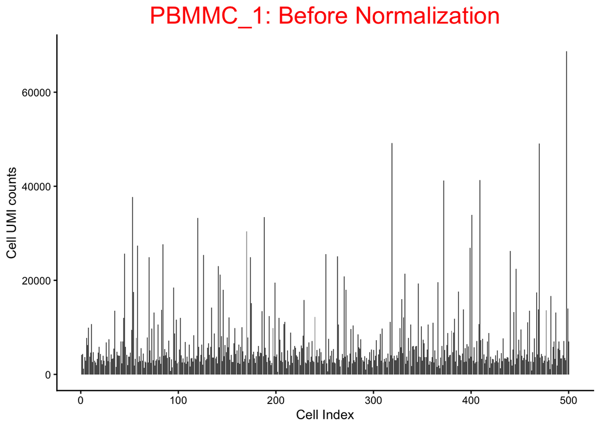

```r
oneSamTab <- seurat_object@meta.data %>%
  filter(orig.ident == "PBMMC-1") %>%
  rownames_to_column("Cell") %>%
  dplyr::select(orig.ident,Cell, nCount_RNA) %>%
  mutate(cell_num = 1:n())

p_before_nom <- ggplot(data=oneSamTab, aes(x=cell_num, y=nCount_RNA)) +
  geom_bar(stat = 'identity') +
  labs( x= 'Cell Index',
        y='Cell UMI counts',
        title = "PBMMC_1: Before Normalization" ) +
  theme_classic() +
  theme(
    plot.title = element_text(hjust = 0.5, size=20, color = 'red')
  )

p_before_nom
```

- Above plot shows the UMI counts/cell (transcript molecules) for 500 cell from the PBMMC_1 sample
- UMI counts fluctuate
- We derive biological insights downstream by comparing cells against each other.
- But the UMI counts differences makes it harder to compare cells.
- Why total transcript molecules (UMI counts) detected between cells differ?
  - Biological:
    - Cell sub type differences, like size and transcription activity etc.
  - Technical: scRNA data is inherently noisy
    - Low mRNA content per cell
    - cell-to-cell differences in mRNA capture efficiency
    - Variable sequencing depth
    - PCR amplification efficiency
- A normalization technique makes the UMI counts distribution uniform, so that each cell has similar counts.
- Normalization is a critical step that corrects cell-to-cell technical differences.
- By normalizing, downstream comparisons of relative expression between cells are valid.